# 02 MNIST_2113오지원

### **문자열 포맷팅(%)**

대표적인 종류 : %s >>문자열," %d >>정수, %f >>실수

자릿수를 지정하는 방법  
정수부 확장 >>%Nd(소숫점 앞으로 N개의 자릿수까지 표현)  
실수부 확장 >>%0.Nf(소숫점 뒤로 N개 자릿수까지 표현)  
⚠️주의

#### *정수부 확장에서 값이 없으면 빈칸으로 자리가 채워진다*

#### *실수부 확장에서 소숫점 2자리까지 표현된수(ex : 2.18)에 대해 %0.5f처럼 지정하면 0으로 채워진다(ex : 2.18000)*

#### *만약 10자리수에 대해서 %5d처럼 지정하면 아무런 일이 일어나지 않는다*

```python
#예제코드
a = "macintosh"
b = 19840124
c = 42.195

print("%s" %a) #문자열
print("%5d" %b) #8자리수에 대해서 정수부 5자리만 지정 >> 아무일도 일어나지 않음
print("%10d" %b) #8자리수에 대해서 정수부 10자리를 지정 >> 앞에 두칸이 빈칸
print("%0.7f" %c) #소숫점 3개까지 나타내어진 수에 대해서 실수부 7자리 지정 >> 뒤에 4칸이 0
print("%0.2f" %c) #소숫점 3개까지 나타내어진 수에 대해서 실수부 2자리 지정 >> 소숫점 두자리까지만
```

```
macintosh
19840124
  19840124
42.1950000
42.20
```

- 인덱스 1번 이미지의 정답은 어디에 있을까?

```python
for i in range(10):
  result = sum(y_train==i) #y_train에서 i와 일치하는 것들의 개수합을 구함
  print(f"{i}의 개수는",result) #출력값을보면 값들의 개수가 비슷한걸 볼 수 있는데 편향이 적다고 볼 수 있다 (학인쌤 피셜 : 하의,신발,상의같은 종류 편향이 크다)
```

```
0의 개수는 5923
1의 개수는 6742
2의 개수는 5958
3의 개수는 6131
4의 개수는 5842
5의 개수는 5421
6의 개수는 5918
7의 개수는 6265
8의 개수는 5851
9의 개수는 5949
```

# Matplotlib으로 데이터 나타내기

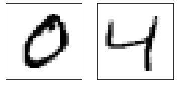

```python
#인덱스 1,2를 1행 2열로 나타내기

import matplotlib.pyplot as plt

plt.subplot(1,2,1) #1행 2열의 1번위치
plt.imshow(x_train[1], cmap='Greys') #그 위치에 x_train[1]을 지정
plt.xticks([]) #x축 눈금 빈리스트로 둬서 없게!
plt.yticks([]) #y축 눈금 빈리스트로 둬서 없게!

plt.subplot(1,2,2) #1행 2열의 2번위치
plt.imshow(x_train[2], cmap='Greys') #그 위치에 x_train[2]을 지정
plt.xticks([]) #x축 눈금 빈리스트로 둬서 없게!
plt.yticks([]) #y축 눈금 빈리스트로 둬서 없게!

plt.show() #이제 보여줘!
```

- matplotlib 이용해 이미지 출력

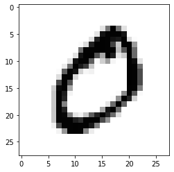

```python
import matplotlib.pyplot as plt
plt.imshow(x_train[1], cmap='Greys')
plt.show()
```

```
[5 0 4 1 9 2 1 3 1 4 3 5 3 6 1 7 2 8 6 9 4 0 9 1 1]
```

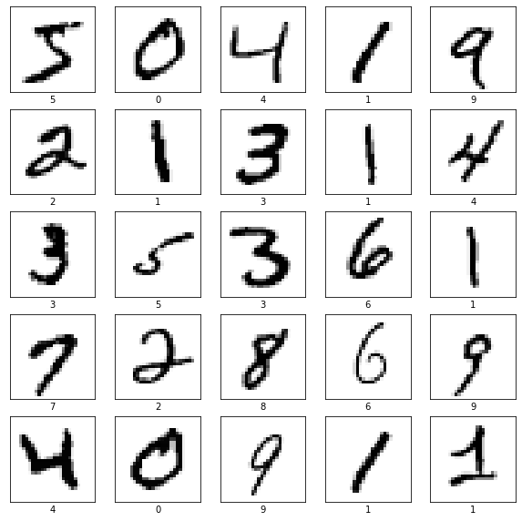

```python
print(y_train[:25]) #0부터 24까지의 index 정답출력

plt.figure(figsize=(10,10)) #각 그래프의 크기를 tuple형으로 받음
for i in range(25):
    plt.subplot(5,5,i+1) #5행 5열로 만들고 i+1위치, 멀티 그래프를 출력할때 사용
    plt.imshow(x_train[i], cmap='Greys') #cmap은 colormap의 약자 autumn(), bone(), cool(), copper()...등이 있다
    plt.xticks([])
    plt.yticks([])
    plt.xlabel(y_train[i]) #원래는 xlabel을 통해 x축이 나타내는걸 적음, 여기선 어떤 수를 그래프에서 표현하는지 알려주는 용도
plt.show()
```

- 숫자 7에 대한 다양한 손글씨를 확인해보자

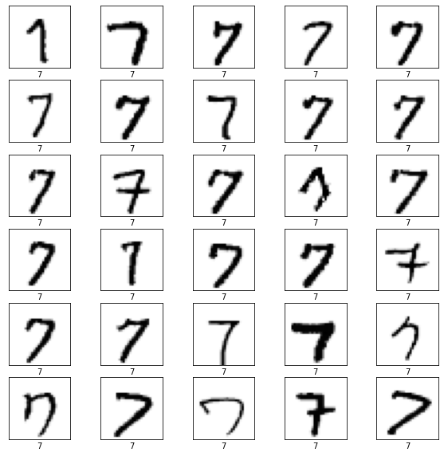

```python
#7만 30개 출력하기

printing = [] #이곳에는 출력할 수의 위치를 저장
for i in range(200,501): #대충 200에서 500사이의 train데이터에 대해서 >> 아무렇게 넓게 범위 잡으면됨
  if y_train[i]==7: #만약 y_train이 7이라면
    printing.append(i)
    if len(printing) == 30: #30개가 꽉차면
      break #반복문 탈출!

plt.figure(figsize=(10,10))
for i in range(30):
    plt.subplot(6,5,i+1) #6행 5열로 만들고 i+1은 위치
    plt.imshow(x_train[printing[i]], cmap='Greys')
    plt.xticks([])
    plt.yticks([])
    plt.xlabel(y_train[printing[i]])
plt.show()
```

## (실습) Fashion MNIST 데이터셋 이해하기

```python
from keras.datasets import fashion_mnist
(x_train, y_train), (x_test, y_test) = fashion_mnist.load_data()
```

```
Downloading data from https://storage.googleapis.com/tensorflow/tf-keras-datasets/train-labels-idx1-ubyte.gz
Downloading data from https://storage.googleapis.com/tensorflow/tf-keras-datasets/train-images-idx3-ubyte.gz
Downloading data from https://storage.googleapis.com/tensorflow/tf-keras-datasets/t10k-labels-idx1-ubyte.gz
Downloading data from https://storage.googleapis.com/tensorflow/tf-keras-datasets/t10k-images-idx3-ubyte.gz
```

1. 훈련데이터와 테스트데이터 모양 확인

```python
print(x_train.shape, x_test.shape)
```

```
(60000, 28, 28) (10000, 28, 28)
```

1. 인덱스 5번 이미지 확인

```python
x_train[5]
```

```
array([[  0,   0,   0,   0,   1,   0,   0,   0,   0,  22,  88, 188, 172,
        132, 125, 141, 199, 143,   9,   0,   0,   0,   1,   0,   0,   0,
          0,   0],
       [  0,   0,   0,   1,   0,   0,  20, 131, 199, 206, 196, 202, 242,
        255, 255, 250, 222, 197, 206, 188, 126,  17,   0,   0,   0,   0,
          0,   0],
       [  0,   0,   0,   1,   0,  35, 214, 191, 183, 178, 175, 168, 150,
        162, 159, 152, 158, 179, 183, 189, 195, 185,  82,   0,   0,   0,
          0,   0],
       [  0,   0,   0,   0,   0, 170, 190, 172, 177, 176, 171, 169, 162,
        155, 148, 154, 169, 174, 175, 175, 177, 183, 188,  12,   0,   0,
          0,   0],
       [  0,   0,   0,   0,  25, 194, 180, 178, 174, 184, 187, 189, 187,
        184, 181, 189, 200, 197, 193, 190, 178, 175, 194,  90,   0,   0,
          0,   0],
       [  0,   0,   0,   0,  42, 218, 191, 197, 208, 204, 211, 209, 210,
        212, 211, 214, 215, 213, 214, 211, 211, 191, 200, 158,   0,   0,
          0,   0],
       [  0,   0,   0,   0,  88, 221, 215, 217, 219, 211, 185, 150, 118,
        107,  99,  88,  83,  90, 135, 212, 203, 207, 219, 169,   0,   0,
          0,   0],
       [  0,   0,   0,   0,   0,  27, 118, 162,  40,   0,   0,   0,  10,
         19,  28,  39,  47,  36,   0,   0, 203, 230, 220, 203,   0,   0,
          0,   0],
       [  0,   0,   0,   0, 138, 136,  71,  69,  54, 216, 217, 203, 184,
        168, 163, 162, 163, 178, 221, 186,  38,  26,   7,   0,   0,   0,
          0,   0],
       [  0,   0,   0,   0,  67, 134, 154, 224, 129,  66,  81, 117, 129,
        128, 132, 137, 131, 129,  86,  73, 157, 151, 134, 216,  18,   0,
          0,   0],
       [  0,   0,   0,   0, 203, 198, 172, 183, 206, 255, 255, 250, 243,
        240, 239, 235, 238, 244, 255, 238, 184, 160,  86,  98,   0,   0,
          0,   0],
       [  0,   0,   0,   0, 122, 188, 224, 151, 105, 127,  97, 100, 105,
        114, 117, 117, 113, 103,  98, 111, 142, 254, 191, 255,  49,   0,
          0,   0],
       [  0,   0,   0,   0, 163, 179, 200,  95, 154, 198, 197, 200, 200,
        198, 197, 198, 199, 202, 200, 176,  86, 206, 157, 162,  10,   0,
          0,   0],
       [  0,   0,   0,   0, 197, 201, 229,  71, 144, 194, 181, 183, 179,
```

[output cut: 29 more lines]

```
       [  0,   0,   0,   5, 183, 208, 127,   0, 197, 166, 153, 149, 149,
        146, 148, 149, 150, 151, 158, 191,  90,   8, 223, 195,  99,   0,
          0,   0],
       [  0,   0,   0,   6, 184, 208, 114,   0, 204, 173, 161, 180, 176,
        172, 173, 173, 174, 176, 162, 202, 115,   0, 229, 199, 105,   0,
          0,   0],
       [  0,   0,   0,   9, 178, 204, 115,   0, 121, 135, 114, 117, 114,
        114, 117, 118, 119, 117, 113, 147,  63,   0, 225, 196, 107,   0,
          0,   0],
       [  0,   0,   0,  18, 180, 206, 131,   0,   0,   0,   0,   0,   0,
          0,   0,   0,   0,   0,   0,   0,   0,   0, 224, 197, 123,   0,
          0,   0],
       [  0,   0,   0,   0, 141, 151,  76,   0,   1,   1,   0,   0,   0,
          0,   0,   0,   0,   0,   0,   0,   0,   0, 133, 167,  73,   0,
          0,   0]], dtype=uint8)
```

1. 인덱스 5번 이미지의 레이블 확인

```python
y_train[5]
```

```
2
```

1. matplotlib 이용해 인덱스 5번 이미지 확인

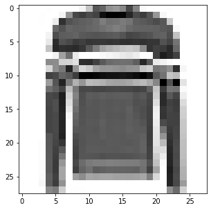

```python
import matplotlib.pyplot as plt
plt.figure(figsize=(5,5))
plt.imshow(x_train[5], cmap='Greys')
plt.show()
```

```python
y_train #이것도 x_train에 대한 정답지(옷 종류 문자열이 아닌 숫자로)
```

```
array([9, 0, 0, ..., 3, 0, 5], dtype=uint8)
```

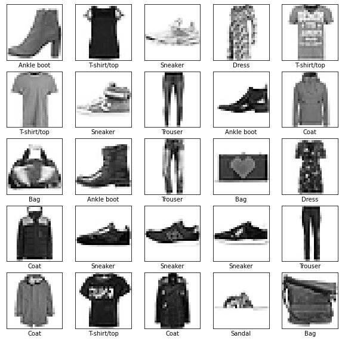

```python
class_names = ['T-shirt/top', 'Trouser', 'Pullover', 'Dress', 'Coat',
               'Sandal', 'Shirt', 'Sneaker', 'Bag', 'Ankle boot']
plt.figure(figsize=(10,10))

#711번~735번 인덱스 이미지

for i in range(711, 711+25): #711부터 735까지 25개 데이터
    plt.subplot(5,5,i+1-711)
    plt.xticks([])
    plt.yticks([])
    plt.imshow(x_train[i], cmap='Greys')
    plt.xlabel(class_names[y_train[i]])  #y_train은 숫자로 주어져 있기 때문에 인덱싱하여 class_names에서 이에 맞는 의류이름을 가져와야함
plt.show()
```

1. 패션 아이템 이미지가 클래스별로 각각 몇 개 있는지 확인해보자.

```python
class_names = ['T-shirt/top', 'Trouser', 'Pullover', 'Dress', 'Coat',
               'Sandal', 'Shirt', 'Sneaker', 'Bag', 'Ankle boot']

for item1 in range(len(class_names)):
  count = 0 #새로운 item(옷 종류)마다 count수를 0으로 초기화
  for item2 in y_train:
    if item1 == item2: #만약 찾고자 하는 item1(옷종류)와 item2(y_train의 옷종류)가 같다면
      count +=1        #개수 추가!
    else:
      pass
  print(f"{class_names[item1]}의 개수는 {count}개") #하나의 item1에 대해서 개수를 출력후 반복문 재개
```

```
T-shirt/top의 개수는 6000개
Trouser의 개수는 6000개
Pullover의 개수는 6000개
Dress의 개수는 6000개
Coat의 개수는 6000개
Sandal의 개수는 6000개
Shirt의 개수는 6000개
Sneaker의 개수는 6000개
Bag의 개수는 6000개
Ankle boot의 개수는 6000개
```

```python
from google.colab import drive
drive.mount('/content/drive')
```

```python
!jupyter nbconvert --to markdown "/content/drive/MyDrive/Colab Notebooks/.ipynb"
```

[output not shown]

[output cut: 106 more lines]

[output not shown]